# Panel Data Models

panel_data_01 · Comparing households with themselves

Does comparing richer and poorer households tell us what happens when the same household’s income changes?

Chapter 15, §§15.1–15.2.4, with an introduction to §15.3 and §§15.3.1–15.3.2.

## Before class

You have already studied omitted-variable bias, dummy variables, endogeneity and the distinction between consistency and efficiency. Today we use repeated observations to remove one specific source of endogeneity: **stable, additive household characteristics**.

Read §§15.1–15.2.4 and the pooled/within portions of the handout, *Comparing Basic Panel Data Estimators* (Version 2.1). The example uses `liquor5` from the textbook website: 40 households, three periods each, 120 observations. `hh` identifies the household; `year` is coded 1–3, indicating calendar years. Both income and liquor expenditure are in thousands of dollars.

**Notation.** We write the household effect as $\alpha_i$ and the idiosyncratic error as $e_{it}$. POE5 writes the household effect as $u_i$. The handout’s notation table maps the symbols.

**After this lecture, you should be able to:**

- Diagnose how stable household characteristics can contaminate a pooled income–expenditure comparison.
- Calculate and interpret a within estimate and explain its equivalence to household dummy-variable OLS.
- Explain what FE removes, what it cannot identify, and why it does not automatically establish causality.

**Must understand:** the source of identifying variation, the cancellation of the household effect, and the remaining exogeneity condition.  
**Reference material:** full derivations and recovery of household slopes and intercepts.

## 0. Retrieval and connection

Suppose a regression of liquor expenditure on income omits stable household preferences. When would that omission bias the income coefficient?

**Expected answer and connection**

Preferences must affect expenditure and be correlated with income. An omitted characteristic does not create slope bias merely because it affects the outcome. Ask next: **Could repeated observations remove stable preferences without measuring them?** This is the bridge from omitted-variable bias and IV to panel data.

## 1. The hook

The pooled regression gives

$$\widehat{\text{liquor}}_{it}=0.93390+0.02707\,\text{income}_{it}.$$

An analyst says: “If this household’s income increases by $1,000, its liquor expenditure will increase by about $27.” Is that defensible, indefensible, or conditional? Give one reason.

**Predict before computing:** Will removing between-household differences increase or decrease the income coefficient? Explain a possible economic mechanism. There is no universal direction of bias.

The units explain the $27 calculation: $0.02707$ thousand dollars is $27.07$. The level-model slope is **not an elasticity**. The harder question is whether the pooled comparison answers a within-household question.

## 2. Minimal theory

### Stable differences and pooling · §§15.1.1, 15.1.3

Write

$$y_{it}=\alpha_i+\beta x_{it}+e_{it}.$$

The intercept $\alpha_i$ collects stable household characteristics. If these characteristics are related to income, the pooled regression puts a correlated omitted component into its error. Observing more households can improve precision without eliminating that problem.

The slope $\beta$ has no household subscript: this is a **common-slope model**. Household fixed effects allow different intercepts, not automatically different slopes. If slopes do differ across households, FE estimates a weighted average of the household-specific slopes (Lab 1.3), not their simple average.

### Why subtraction helps · §§15.2.1–15.2.3

With two periods,

$$y_{i2}-y_{i1}=\beta(x_{i2}-x_{i1})+(e_{i2}-e_{i1}).$$

The stable household effect cancels. For more periods, subtract the household mean:

$$\bar y_i=\alpha_i+\beta\bar x_i+\bar e_i,$$

$$y_{it}-\bar y_i=\beta(x_{it}-\bar x_i)+(e_{it}-\bar e_i).$$

We compare expenditure above or below a household’s usual level with income above or below that **same household’s** usual level.

Your handout’s sums of squares make this familiar OLS calculation explicit:

$$W_{xx}=\sum_i\sum_t(x_{it}-\bar x_i)^2,\qquad
W_{xy}=\sum_i\sum_t(x_{it}-\bar x_i)(y_{it}-\bar y_i),$$

$$\hat\beta_{\mathrm{FE}}=\frac{W_{xy}}{W_{xx}}.$$

For two periods, the FE and first-difference slopes agree when the specifications and samples match. For more than two periods, they need not agree.

### What remains assumed · §15.1.2

$$E(e_{it}\mid x_{i1},\ldots,x_{iT},\alpha_i)=0.$$

FE allows income to be correlated with $\alpha_i$. It does not allow income at any date to be arbitrarily related to the time-varying error. A health event affecting both earnings and expenditure, or feedback from a current shock to future earnings, can violate strict exogeneity.

Why *strict* rather than contemporaneous exogeneity? The demeaned regressor $x_{it}-\bar x_i$ contains income from every period, and the demeaned error $e_{it}-\bar e_i$ contains the errors from every period (§15.2.2). A correlation between income at any date and the error at any date can therefore contaminate the within comparison.

FE also assumes that $\alpha_i$ is genuinely stable over the sample. That is more plausible over three periods than over twenty-five (§15.1.1).

### What disappears · §15.2.3

For a time-invariant covariate, $z_i-\bar z_i=0$. Its separate coefficient is unidentified in household FE. This does **not** show that its economic effect is zero.

### Why inference must respect households · §§15.3, 15.3.1–15.3.2

In the pooled model, the error contains the household effect: $v_{it}=(\alpha_i-\alpha)+e_{it}$. Unless households are identical, $\operatorname{cov}(v_{it},v_{is})=\sigma^2_\alpha$ for $t\neq s$ (eq. 15.27), so observations on the same household are not independent pieces of information. FE removes $\alpha_i$, but serial correlation or heteroskedasticity in $e_{it}$ may remain. Household-clustered standard errors allow arbitrary correlation within each household. With 40 households, the number of clusters is the effective sample size for inference. Lecture 2 develops this.

## 3. The econometric lab

Open `panel_data_01.R`. It loads `tidyverse`, `plm`, `sandwich` and `lmtest`, and reads `liquor5` from the textbook website. Run one numbered section at a time. Blocks marked `[EXTRA]` are optional; they are listed under *Self-study extensions* below.

### Lab 1.1 · Where is the income variation?

**Question:** How much variation comes from changes within households? **Prediction:** Is that a small or large share?

**R action:** Compute household means, deviations and the within share.

```r
panel <- panel |>
  group_by(hh) |>
  mutate(
    income_mean = mean(income), liquor_mean = mean(liquor),
    income_within = income - income_mean,
    liquor_within = liquor - liquor_mean
  ) |>
  ungroup()
Wxx <- sum(panel$income_within^2)
Txx <- sum((panel$income - mean(panel$income))^2)
within_share <- Wxx / Txx
within_share
```

**Result:** The within share is **3.78%**. For liquor expenditure, the within share is 32%.  
**Interpretation:** Almost all total income variation separates households with different average incomes; expenditure moves much more within households than income does. **Decision:** The pooled slope may be dominated by comparisons other than the one we want. Expect the within estimate to be imprecise: little identifying income variation remains.

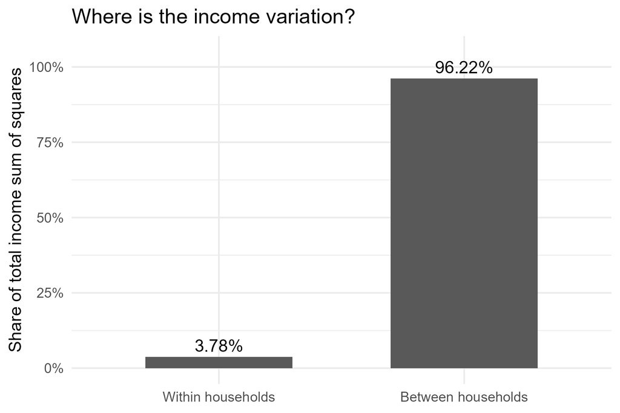

Income variation: only 3.78% is within households.

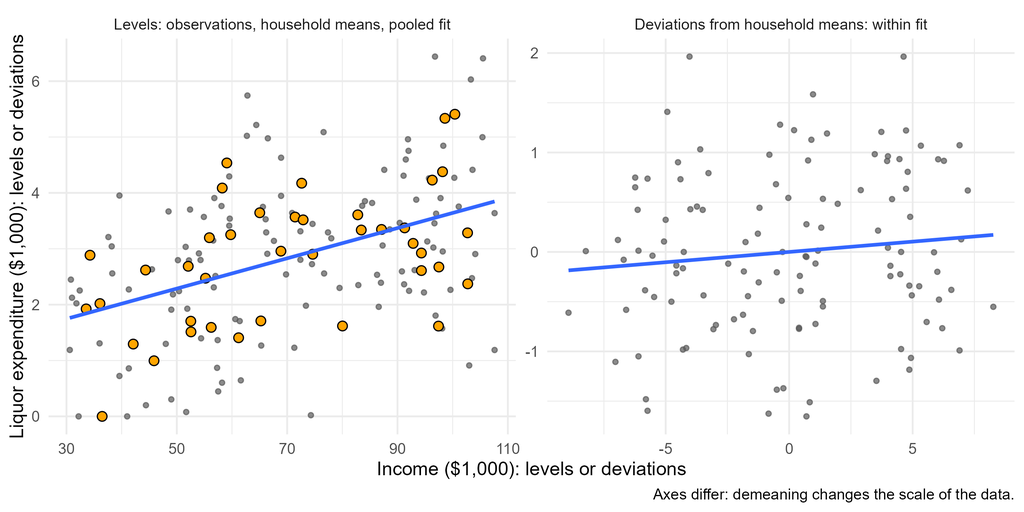

Left: observations and household means, with the pooled fit. Right: deviations from each household’s mean and the within fit. Axes differ because the transformations change the scale of the data.

### Lab 1.2 · Which comparison does pooling resemble?

**Question:** Is pooling close to the relationship between household means?  
**Prediction:** Given Lab 1.1, expect it to be close.

```r
pooled <- lm(liquor ~ income, data = panel)
household_means <- panel |>
  distinct(hh, income_mean, liquor_mean)
between <- lm(liquor_mean ~ income_mean, data = household_means)
coef(pooled)
coef(between)
```

**Result:** Pooled slope **0.02707**; between slope **0.02732**.  
**Interpretation:** Pooling closely resembles the between-household relationship.  
**Decision:** Do not assume this is the response to a change in one household’s income.

Ask: Would adding more households necessarily fix that interpretation?  
**No:** greater precision does not change the comparison or remove correlated omitted characteristics.  
**Decision:** Continue to interpret the pooled estimate as a weighted average of within and between relationships.

### Lab 1.3 · What changes when a household is compared with itself?

**Question:** What is the within slope?  
**Prediction:** Revisit your initial prediction and its economic explanation.

```r
within_manual <- lm(
  liquor_within ~ 0 + income_within, data = panel
)
sum(panel$income_within * panel$liquor_within) /
  sum(panel$income_within^2)
coef(within_manual)
```

**Result:** $W_{xx}=2205.24$, $W_{xy}=45.7413$, and $\hat\beta_{\mathrm{FE}}=0.0207421$. A $1,000 increase corresponds to **$20.74** in the fitted within relationship.

**Interpretation:** The estimated within relationship is smaller than the pooled relationship.  
**Decision:** Update the estimated magnitude, but do not treat the difference as proof of causality or proof of a statistically significant FE–pooled difference.

This manually demeaned regression verifies the coefficient. Its default OLS standard errors are not the final panel inference (see Lab 1.4).

**Connect Labs 1.1–1.3.** In a balanced panel, the pooled slope is an exact weighted average of the within and between slopes, with the variation shares from Lab 1.1 as weights:

$$\hat\beta_{\mathrm{pooled}}=\frac{W_{xx}}{T_{xx}}\,\hat\beta_{\mathrm{FE}}+\frac{B_{xx}}{T_{xx}}\,\hat\beta_{\mathrm{between}}
=0.0378\times0.02074+0.9622\times0.02732=0.02707.$$

Pooling resembles the between regression because 96% of the weight is on between-household comparisons.

Which households supply the FE estimate? All of them, with weights: $\hat\beta_{\mathrm{FE}}=\sum_i (W_{xx,i}/W_{xx})\,\hat\beta_i$, where $\hat\beta_i$ is household $i$’s own OLS slope. In these data the weights range from 0.2% to 6.2%; households whose income changed more carry more weight. The simple average of the household slopes is 0.0263, not 0.0207.

### Lab 1.4 · Are dummy variables and demeaning different estimators?

**Question:** Does explicitly fitting household intercepts give the same income slope?  
**Prediction:** It should on the same sample.

```r
fixed_dummies <- lm(liquor ~ income + factor(hh), data = panel)
coef(fixed_dummies)["income"]
fixed <- plm(liquor ~ income, data = panel,
             index = c("hh", "year"),
             model = "within", effect = "individual")
coef(fixed)
```

**Result:** The slope is **0.0207421** in each implementation.  
**Interpretation:** These are equivalent ways to remove the household intercept.  
**Decision:** Use an implementation convenient for the task; the identifying comparison is unchanged.

**Check the standard errors, not only the slope.** The manually demeaned regression reports a conventional SE of 0.01704; LSDV and `plm` report 0.02091. `lm()` on demeaned data does not know that 40 household means were estimated. Multiplying by $\sqrt{(NT-1)/(NT-N-1)}=\sqrt{119/79}$ reproduces the correct value (Examples 15.4–15.5).

The F-test that all 40 household intercepts are equal gives $F=3.18$ ($p<0.001$; eq. 15.20). A student concludes: “So the pooled income slope is biased.” Is that justified? Connect your answer to the retrieval question.

**Expected answer**

No. The test shows that household intercepts differ. Bias in the pooled slope additionally requires those differences to be correlated with income. Heterogeneity is not endogeneity. The conventional F-test also assumes homoskedastic, serially uncorrelated errors.

### Lab 1.5 · Does FE settle the substantive question?

**Question:** What does the estimate justify?  
**Prediction:** Identify a remaining time-varying threat before looking at the interval.

```r
# Household-clustered CR1 with t(G - 1), G = 40 households
vc_fe_cluster <- vcovCL(within_manual, cluster = ~hh, type = "HC1")
fe_inference <- coeftest(within_manual, vcov. = vc_fe_cluster, df = G - 1)
fe_inference
coefci(within_manual, vcov. = vc_fe_cluster, df = G - 1)
```

| Income slope | Household-clustered SE | 95% interval | Two-sided p-value |
| --- | --- | --- | --- |
| 0.020742 | 0.019427 | [−0.018553, 0.060037] | 0.2922 |

**Interpretation:** The estimated within response is positive but uncertain. In dollars, the interval runs from about −$19 to $60 per $1,000 of income. It includes zero and economically meaningful positive responses. It does not establish that the true effect is zero.

Two things to notice. The clustered SE (0.0194) is *smaller* than the conventional FE SE (0.0209): clustering does not always inflate standard errors. And inference uses $t_{39}$, because with clustered errors the 40 households, not the 120 observations, are the effective sample.

**Decision:** Report a positive, uncertain within association, and state the exogeneity assumptions required for a causal interpretation. Lecture 2 develops why clustered inference is appropriate.

**Deliberate misconception:** “We included household fixed effects, so we have established a positive causal income effect.” What are the two separate problems with this conclusion?

**Correction**

Removing stable additive household effects does not establish exogeneity of income relative to the remaining error. Separately, the within estimate is imprecise. Identification and uncertainty are different questions.

## 4. The AI audit

Copy this prompt and evaluate the response. The purpose is to defend an econometric argument even if the AI’s initial answer is good.

> A balanced panel contains 40 households observed for three periods. Income and liquor expenditure are in thousands of dollars. The pooled income coefficient is 0.02707, the between coefficient is 0.02732, and the household fixed-effects coefficient is 0.02074. Only 3.78% of total income variation is within households. The household-clustered FE standard error is 0.01943.

> Evaluate: “An additional $1,000 of income causes a household to spend $20.74 more on liquor, because household fixed effects eliminate omitted-variable bias.” Explain the comparison behind each estimator, interpret the units, assess uncertainty, and state the assumptions still needed. Use fewer than 200 words.

**Audit:** Does the response (1) distinguish within and between comparisons, (2) get the dollar units right, (3) limit FE’s protection to stable additive effects, and (4) separate imprecision from a zero effect?

**Stress-test prompt:**

> Suppose an unexpected health event changes both income and liquor expenditure. Explain whether household fixed effects remove this problem and what additional evidence or design you would seek.

**Expected reasoning:** A time-varying common cause remains. Measuring the event and relevant controls may help if sufficient; an exogenous source of income variation could support a stronger design. A generic suggestion to “add controls” needs an explanation of what confounding it would remove.

**Check with a simulation (R script, Section 4).** With a true effect of 0.02 and stable preferences correlated with income, pooled OLS gives 0.064 while FE gives 0.019. Adding a time-varying health shock that lowers income and raises liquor spending moves the FE estimate to −0.017. More households do not remove either bias.

## 5. Exit problem

A firm panel relates output to employment and includes firm fixed effects. Factory location never changes during the sample. Software drops location. A student concludes: “Location does not affect output.” Is this justified?

**Expected answer and misconceptions**

No. The separate location coefficient is unidentified because location is constant within each firm and absorbed by firm effects. A dropped variable is not a zero effect. Adding more firms creates no within-firm location variation. Removing FE restores estimability but does not itself establish a credible coefficient.

**Follow-up.** A colleague estimates the same model with firm dummies in `lm()`. Location is *not* dropped; it gets a coefficient of 1.06. Does that change your answer?

**Expected answer**

No. Location is perfectly collinear with the firm dummies. The software dropped a firm dummy instead, so the “location coefficient” is a contrast between firm intercepts, and its value depends on the order of the columns. The R script shows this with a constructed household-level indicator in `liquor5`: 1.058 when it is listed before `factor(hh)`, `NA` when listed after.

**Next:** Can we use between-household information under additional assumptions? Continue with `panel_data_02`.

*Preview:* add each household’s mean income to the pooled regression. The income coefficient becomes exactly the FE slope, 0.02074, and the coefficient on mean income equals $\hat\beta_{\mathrm{between}}-\hat\beta_{\mathrm{FE}}=0.0066$ (the Mundlak approach, §15.4.3).

## Self-study extensions · `[EXTRA]` blocks in the R script

| Extension | Textbook link | Result in `liquor5` |
| --- | --- | --- |
| FE as a weighted average of household slopes | Handout | Weights 0.2%–6.2%; simple average of slopes 0.0263 |
| First differences versus within | §§15.2.1–15.2.2, Exercise 15.17a | $T=3$: FD 0.0297, FE 0.0207; periods 2–3 only: both 0.0393 |
| Frisch–Waugh–Lovell | §15.2.4, Exercise 15.16d | Residualising on household dummies equals demeaning |
| Degrees-of-freedom correction | Examples 15.4–15.5, Exercise 15.16e | $0.01704\times\sqrt{119/79}=0.02091$ |
| Recovering household intercepts | Example 15.6 | `fixef()` equals $\bar y_i-\hat\beta_{\mathrm{FE}}\bar x_i$ |
| F-test for household differences | Eq. 15.20, Exercise 15.16c | $F(39,79)=3.18$, $p<0.001$ |
| Alternative standard errors | Tables 15.3–15.4 | Pooled: 0.0053 conventional, 0.0077 clustered |
| Simulation with a known effect | AI audit stress test | FE removes stable, not time-varying, confounding |
| Mundlak regression | §15.4.3 | FE slope reproduced; mean-income coefficient 0.0066 |

## Assessment practice

**Constructed examination example; not liquor data.** Shops are observed over time. Sales and advertising are in thousands of dollars:

$$\text{sales}_{it}=a_i+\beta\,\text{advertising}_{it}+\varepsilon_{it}.$$

Pooled OLS gives $\hat\beta=4.0$; shop FE gives $\hat\beta=1.5$.

### Part A · individual reasoning

1. Interpret the FE coefficient for a $2,000 advertising increase.
2. Suggest a stable omitted characteristic that could help explain the larger pooled slope.
3. Can FE identify a separate effect of a location category that never changes?
4. Managers increase advertising when they anticipate unusually strong demand. Does shop FE resolve this?
5. The panel is balanced, and 10% of the total variation in advertising is within shops. What between-shop slope do the two estimates imply?

**Solutions**

1. Fitted sales are $3,000 higher in the within-shop relationship. Causality requires exogeneity.
2. A favourable location could raise sales and be associated with larger advertising budgets. This is plausible, not proved by the coefficient difference.
3. No; the category has no within-shop variation.
4. No; time-varying anticipated demand may remain correlated with advertising.
5. $4.0=0.1\times1.5+0.9\,\hat\beta_{\mathrm{between}}$, so $\hat\beta_{\mathrm{between}}=3.85/0.9\approx4.28$. The pooled slope is close to the between slope because most advertising variation is between shops.

### Part B · AI allowed

Write a 200-word evaluation of a manager’s recommendation to increase advertising because the FE slope is positive. Explain what the estimate measures, one remaining identification threat, and additional evidence that would strengthen the recommendation.

| Level | Evidence in the answer |
| --- | --- |
| Insufficient | Repeats the coefficient or treats FE as automatically causal |
| Competent | Correct interpretation, a relevant threat and a reasonable additional check |
| Strong | Connects the threat to exogeneity and explains how the proposed evidence would address it |

## Instructor notes · reveal as needed

**Instructor-only teaching notes**

- **Most important idea:** Identify the comparison supplying the coefficient before interpreting it.
- Likely misconceptions: FE means different slopes; time-invariant covariates have zero effects; an insignificant estimate proves no effect; FE eliminates all endogeneity.
- Discussion may take longer around strict exogeneity and feedback. Use the health-event example rather than a lengthy derivation.
- If short of time, show only the income row of the dummy-variable model. Keep the equivalence, skip the intercept output. The SE check in Lab 1.4 and the household-weight paragraph in Lab 1.3 can move to self-study; keep the F-test question and the exit-problem follow-up, which are the Evaluate-level additions.
- If the class is quiet: “Which comparison would you want for predicting a change in this household’s income?”
- Likely AI responses recommend FE automatically. Ask which error component FE removes and what remains.
- Do not call the 3.78% sum-of-squares share the percentage of observations used. All households with useful within variation contribute; the weights $W_{xx,i}/W_{xx}$ (0.2%–6.2%) show exactly how much.
- If students ask for “robust” standard errors: White heteroskedasticity-robust SEs are not valid for FE when $T>2$ (POE5 footnote 9). Cluster by household.
- Strict exogeneity has a testable implication: future income should not enter the FE regression (Wooldridge 2010, ch. 10). With $T=3$ the lead leaves only two periods, so treat it as an illustration, not a test with much power.
- Household-clustered CR1 uses $G/(G-1)\,(n-1)/(n-k)$ and $t_{39}$ intervals. In the demeaned slope regression, $k=1$. `vcovCL(type = "HC1")` on the demeaned regression and `plm`’s `vcovHC(type = "sss", cluster = "group")` both give 0.019427. Clustering the LSDV `lm()` counts the 40 dummies ($k=41$) and gives 0.02384. Other software may count absorbed effects differently; do not mix conventions.

## Sources and reproducibility

Hill, Griffiths and Lim, *Principles of Econometrics*, 5th ed., Chapter 15, especially §§15.1–15.3.2.  
Handout *Comparing Basic Panel Data Estimators* (Version 2.1).  
R script `panel_data_01.R`.  
Wooldridge, J. M. (2013), *Introductory Econometrics: A Modern Approach*, 5th ed., Chapter 13-14.  
Data: [liquor5 definition file](https://www.principlesofeconometrics.com/poe5/data/def/liquor5.def) and accompanying R data file: http://www.principlesofeconometrics.com/poe5/data/rdata/liquor5.rdata.